# Module–Trait Association — Spinal Cord (Bulk RNA-seq)

Extended Analysis: Age, FTD/AD Comorbidity, Site of Motor Onset

ALS Deconvolution Project

2026-04-28

> **What this analysis adds:** Extends the original Spinal Cord WGCNA module–trait correlation (ALS, Sex, RIN, C9ORF72) with three new trait categories:
> - **Age at Death** — assesses age-associated transcriptional variation independent of ALS.
> - **FTD/AD Comorbidity** — binary indicator (1 if `Subject.Group.Subcategory` mentions Frontotemporal Dementia or Alzheimer’s Disease). Notably, FTD/AD comorbidity is rarer in spinal cord ALS than frontal/motor cortex cohorts, and truly spinal-cord-specific ALS modules should *not* correlate with cortical neurodegeneration markers.
> - **Site of Motor Onset** — three dummy columns (Limb, Bulbar, Axial) using the same encoding as the frontal and motor cortex analyses, enabling cross-region comparison of onset-linked modules.

> **Biological context:** The spinal cord is the primary site of lower motor neuron degeneration in ALS. Modules significantly associated with ALS **and** independent of RIN here likely reflect direct neuronal loss, glial reactivity, or neuromuscular junction dysfunction in the cord — distinct from the cortical signatures seen in frontal/motor cortex.

**Dataset:** Spinal Cord — Bulk RNA-seq | **Retained samples:** 441 | **Non-grey modules:** 34

# 1 Metadata Encoding

Summary of new trait encoding

| Category | Full cohort (n) | Retained in WGCNA (n) |
| --- | --- | --- |
| FTD/AD (= 1) | 77 | 71 |
| FTD/AD absent (= 0) | 526 | 370 |
| Onset: Limb | 362 | 257 |
| Onset: Bulbar | 159 | 117 |
| Onset: Axial | 27 | 22 |
| Age: available | 592 | 430 |

# 2 Full Module–Trait Heatmap

All 34 non-grey modules × 9 traits.

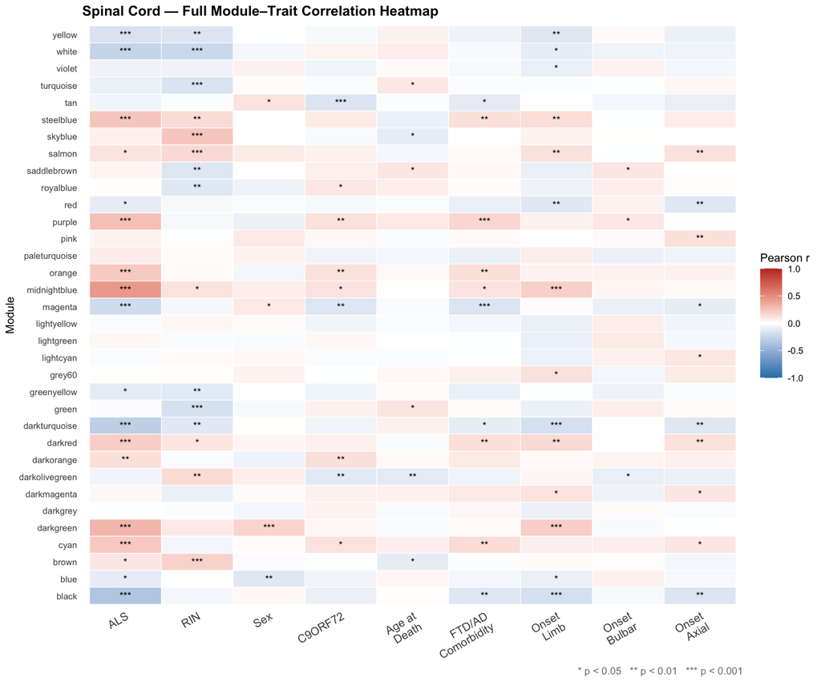

# 3 Filtered Modules: ALS p < 0.05 and RIN p > 0.05

**9 module(s) passed the filter:**

Filtered modules: ALS-significant and RIN-independent

| Module | r (ALS) | p (ALS) | r (RIN) | p (RIN) | r (Age) | p (Age) | r (FTD/AD) | p (FTD/AD) | Direction |
| --- | --- | --- | --- | --- | --- | --- | --- | --- | --- |
| blue | -0.110 | 2.11e-02 | 0.004 | 0.9310 | 0.040 | 0.4030 | -0.055 | 0.246000 | DOWN in ALS ↓ |
| magenta | -0.210 | 8.40e-06 | -0.043 | 0.3710 | -0.029 | 0.5430 | -0.158 | 0.000853 | DOWN in ALS ↓ |
| black | -0.357 | 0.00e+00 | -0.049 | 0.3010 | 0.009 | 0.8510 | -0.142 | 0.002830 | DOWN in ALS ↓ |
| darkorange | 0.130 | 6.10e-03 | -0.020 | 0.6790 | 0.020 | 0.6750 | 0.089 | 0.061600 | UP in ALS ↑ |
| orange | 0.222 | 2.50e-06 | 0.021 | 0.6640 | 0.024 | 0.6130 | 0.129 | 0.006710 | UP in ALS ↑ |
| red | -0.111 | 1.99e-02 | -0.038 | 0.4230 | -0.025 | 0.5950 | -0.092 | 0.052700 | DOWN in ALS ↓ |
| darkgreen | 0.306 | 0.00e+00 | 0.087 | 0.0685 | -0.029 | 0.5380 | 0.015 | 0.748000 | UP in ALS ↑ |
| cyan | 0.224 | 2.00e-06 | -0.053 | 0.2650 | 0.065 | 0.1740 | 0.144 | 0.002410 | UP in ALS ↑ |
| purple | 0.261 | 0.00e+00 | -0.035 | 0.4630 | 0.087 | 0.0687 | 0.170 | 0.000331 | UP in ALS ↑ |

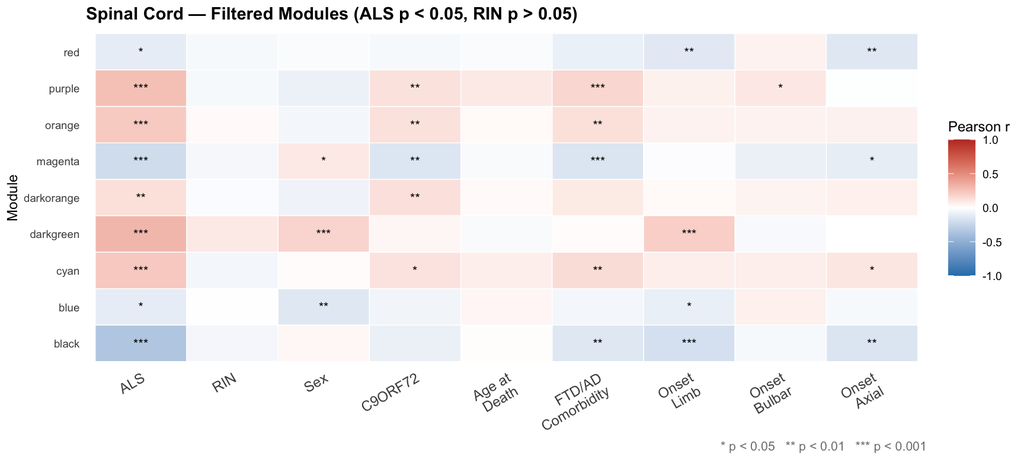

# 4 ALS Association Direction — Bar Graph

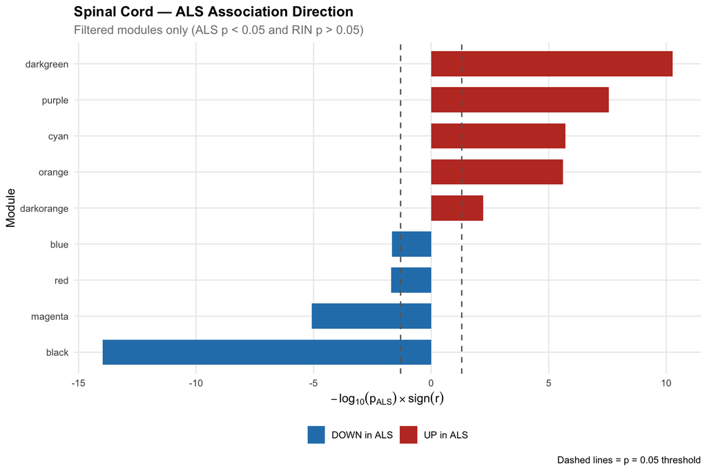

# 5 Summary & Brief Analysis

**9 module(s)** survived the dual filter: **5 up-regulated** and **4 down-regulated** in ALS.

- The spinal cord hosts the lower motor neurons that degenerate first and most severely in ALS. Down-regulated modules likely reflect neuronal loss (excitatory motor neuron gene programs), while up-regulated modules may capture reactive astrogliosis, microgliosis, or compensatory axonal sprouting.
- Site of Motor Onset associations are particularly informative here: bulbar-onset ALS may show distinct cervical spinal cord changes vs. limb-onset ALS (which predominantly affects lumbar cord). Since this dataset pools multiple spinal cord segments, onset-linked module associations represent a signal averaged across segments.
- Modules correlated with Age should be considered carefully — post-mortem spinal cord from older donors may have more baseline neuronal attrition independent of ALS.

*Generated by `SC_Subset_Analysis.Rmd` | WGCNA module structure from existing bulk Spinal Cord network | Extended trait matrix: ALS, RIN, Sex, C9ORF72, Age, FTD/AD, Onset (Limb/Bulbar/Axial)*